# Python MFTE evaluation

Elen Le Foll

06/05/2023

# Data import

These chunks import the data directly from the Excel files in which we did the manual tag check and corrections. Warning messages that Tag4 columns are unknown or uninitialised can safely be ignored.

```r
EvalData <- readRDS(here("evaluation", "MFTE_Python_Eval_Results.rds")) #
summary(EvalData)
```

```
##                  FileID          Corpus            Register         Output
##  COCA_Spoken_4082518: 4418   BNC2014:33302   academic  : 5494   ._.    : 2226
##  BNC_Sp2m2f63       : 2174   COCA   :27852   e-language:19583   ,_,    : 2224
##  BNC_FictFan41      : 1959                   fiction   : 7273   the_DT : 2007
##  BNC_NewReBet1393   : 1919                   news      :14936   to_IN  : 1231
##  BNC_BERe31         : 1868                   spoken    :11327   and_CC : 1166
##  BNC_Sp3m1f10       : 1787                   TV/movies : 2541   (Other):52252
##  (Other)            :47029                                      NA's   :   48
##      Token            Tag           TagGold      Evaluation
##  ,      : 2223   NN     :11898   NN     :11792   Mode :logical
##  .      : 2220   IN     : 6633   IN     : 6563   FALSE:1906
##  the    : 2002   DT     : 3542   DT     : 3540   TRUE :59248
##  to     : 1245   VPRT   : 2853   VPRT   : 2895
##  and    : 1166   .      : 2769   .      : 2767
##  (Other):52264   ,      : 2471   ,      : 2469
##  NA's   :   34   (Other):30988   (Other):31128
```

```r
# Total number of tags manually checked
nrow(EvalData) # 61154
```

```
## [1] 61154
```

```r
# Number of tags evaluated per file
EvalData %>%
  group_by(FileID) %>%
  count(.) %>%
  arrange(desc(n))
```

```
## # A tibble: 60 × 2
## # Groups:   FileID [60]
##    FileID                  n
##    <fct>               <int>
##  1 COCA_Spoken_4082518  4418
##  2 BNC_Sp2m2f63         2174
##  3 BNC_FictFan41        1959
##  4 BNC_NewReBet1393     1919
##  5 BNC_BERe31           1868
##  6 BNC_Sp3m1f10         1787
##  7 BNC_FictMis228       1658
##  8 AcaHumBk34           1562
##  9 BNC_ElanForumRig1    1456
## 10 BNC_ElanRev27        1423
## # ℹ 50 more rows
```

```r
# Number of tokens evaluated per corpus and register subcorpus
EvalData %>%
  group_by(Corpus, Register) %>%
  count() %>%
  #arrange(-n) %>%
  as.data.frame()
```

```
##     Corpus   Register     n
## 1  BNC2014   academic  2617
## 2  BNC2014 e-language 13830
## 3  BNC2014    fiction  4144
## 4  BNC2014       news  7399
## 5  BNC2014     spoken  5312
## 6     COCA   academic  2877
## 7     COCA e-language  5753
## 8     COCA    fiction  3129
## 9     COCA       news  7537
## 10    COCA     spoken  6015
## 11    COCA  TV/movies  2541
```

```r
EvalData %>%
  group_by(Corpus, Register) %>%
  count(FileID) %>%
  print(n = 100)
```

```
## # A tibble: 60 × 4
## # Groups:   Corpus, Register [11]
##    Corpus  Register   FileID                   n
##    <fct>   <fct>      <fct>                <int>
##  1 BNC2014 academic   AcaHumBk34            1562
##  2 BNC2014 academic   BNC_BAcjH78            522
##  3 BNC2014 academic   BNC_BAcjM107           533
##  4 BNC2014 e-language BNC_BEBl293            660
##  5 BNC2014 e-language BNC_BEEm76             574
##  6 BNC2014 e-language BNC_BERe31            1868
##  7 BNC2014 e-language BNC_ElanBlogBla12      671
##  8 BNC2014 e-language BNC_ElanBlogSlu30      761
##  9 BNC2014 e-language BNC_ElanEmail102      1390
## 10 BNC2014 e-language BNC_ElanForumCar5     1368
## 11 BNC2014 e-language BNC_ElanForumRig1     1456
```

[output cut: 49 more lines]

```r
660+671+761 # BNC blogs
```

```
## [1] 2092
```

```r
574+1390 # BNC e-mails
```

```
## [1] 1964
```

```r
1368+1454 # BNC forums
```

```
## [1] 2822
```

```r
1868+1423 # BNC review
```

```
## [1] 3291
```

```r
1306+675+1282 # BNC social media
```

```
## [1] 3263
```

```r
1308+1055 # BNC magazines
```

```
## [1] 2363
```

```r
745+643+814 # COCA magazines
```

```
## [1] 2202
```

```r
540+595+606+601 # COCA news articles
```

```
## [1] 2342
```

```r
556+541+1357+539 # COCA opinion
```

```
## [1] 2993
```

# Analysis

```r
nrow(EvalData) # 61154 tags manually checked
```

```
## [1] 61154
```

```r
summary(EvalData$TagGold) # 294 UNCLEAR
```

```
##     -LRB-     -RRB-         ,         :         .        ''         "        ``
##       154       159      2469       323      2767       273        11       192
##         $      ABLE       ACT       AFX       AMP     BEAUX      BEMA        CC
##        10        19       124         2       137       363      1319      1834
##        CD      CONC      COND      CONT       CUZ      DEMO       DMA     DOAUX
##       781        74       152       994        74       567       286       246
##        DT      DWNT      ELAB       EMO      EMPH        EX      FPUH      FREQ
##      3540        91        44        20       251       107       233       218
##        FW       GTO        GW       HDG      HGOT       HST      HYPH        IN
##         2        37        16        69        33        96        38      6563
##      JJAT      JJPR      LIKE      MDCA      MDCO      MDMM      MDNE   MDother
##      2234       948        81       168        68        69       170         1
##      MDWO      MDWS     NCOMP       NFP        NN NNMention      NONE      PASS
##       137       154      1007         1     11792         6       190       358
##      PEAS      PGET       PIT     PLACE    POLITE       POS      PP1P      PP1S
##       494        15       781       240        75       184       403      1230
##       PP2      PP3f      PP3m      PP3t   PPother      PROG      QUAN      QUPR
##       679       483       444       463        10       287       661       206
##     QUTAG        RB        RP        SO     SPLIT      STPR       SYM     THATD
##        34      1049       321       126       224        34       139       185
##      THRC      THSC      TIME   UNCLEAR       URL        VB       VBD       VBG
##       124       213       321       294         9      1865      1762       635
##       VBN      VIMP      VPRT      WHQU      WHSC        WQ       XX0      YNQU
##       379       215      2895       119       591       104       618       171
```

```r
BinomCI(294, 61154,
        conf.level = 0.95,
        sides = "two.sided",
        method = "wilsoncc") * 100
```

```
##            est    lwr.ci    upr.ci
## [1,] 0.4807535 0.4281848 0.5396357
```

```r
data <- EvalData %>%
  filter(!TagGold %in% c("UNCLEAR","unclear")) %>%
  filter(!TagGold %in% c("ACT", "NFP", "GW", "HYPH", "ADD", "AFX", "FW", "WQ", "SYM", "WDT", "MDother")) %>%
  filter(!Tag %in% c("ACT", "NFP", "GW", "HYPH", "ADD", "AFX", "FW", "WQ", "SYM", "WDT", "MDother")) %>%
  filter(TagGold %in% c(str_extract(Tag, "[A-Z0-9]+"))) %>% # Remove all punctuation tags which are uninteresting here.
  droplevels(.) %>%
  mutate(Tag = factor(Tag, levels = union(levels(Tag), levels(TagGold)))) %>% # Ensure that the factor levels are the same for the next caret operation
  mutate(TagGold = factor(TagGold, levels = union(levels(Tag), levels(TagGold))))

# Spot gold tag corrections that are not actually errors
data[data$Tag==data$TagGold & data$Evaluation == FALSE,] %>% as.data.frame() # Should be zero!
```

```
## [1] FileID     Corpus     Register   Output     Token      Tag        TagGold
## [8] Evaluation
## <0 rows> (or 0-length row.names)
```

```r
nrow(EvalData) - nrow(data) # 8506 tags excluded from further analysis because not tallied in MFTE tabular outputs
```

```
## [1] 8506
```

```r
nrow(data) # Number of relevant tags (actually included in MFTE outputs) = 52648
```

```
## [1] 52648
```

```r
summary(data$Evaluation) # Of those: 51139 = TRUE
```

```
##    Mode   FALSE    TRUE
## logical    1509   51139
```

```r
BinomCI(51139, 52648,
        conf.level = 0.95,
        sides = "two.sided",
        method = "wilsoncc") * 100
```

```
##           est   lwr.ci   upr.ci
## [1,] 97.13379 96.98682 97.27385
```

```r
summary(data$TagGold)
```

```
##    ABLE     AMP   BEAUX    BEMA      CC      CD    CONC     CUZ    DEMO     DMA
##      19     137     363    1319    1834     779      74      74     567     286
##   DOAUX      DT    DWNT    ELAB    EMPH      EX    FREQ      IN    JJAT    JJPR
##     241    3540      91      44     251     107     218    6563    2234     948
##    MDCA    MDCO    MDMM    MDWO   NCOMP      NN    NONE    PASS    PEAS     PIT
##     168      68      69     137    1007   11792     189     358     494     781
##   PLACE     POS    PP1P PPother    PROG    QUAN    QUPR      RB   SPLIT   THATD
##     240     184     403       0     287     661     206    1049     224     185
##    THRC    THSC    TIME      VB     VBG     VBN    VIMP    VPRT    WHSC     XX0
##     124     213     321    1865     635     379     215    2895     591     618
##    CONT    PP1S      RP     VBD    MDNE     URL    COND    LIKE    MDWS     PP2
##     994    1230     321    1761     170       9     152      81     154     679
##      SO    YNQU     EMO    FPUH  POLITE    WHQU     HDG    STPR    PGET     GTO
##     126     161      19     233      75     119      69      34      15      37
##    HGOT     HST   QUTAG
##      33      95      34
```

```r
levels(data$TagGold) # Should be 73 features
```

```
##  [1] "ABLE"    "AMP"     "BEAUX"   "BEMA"    "CC"      "CD"      "CONC"
##  [8] "CUZ"     "DEMO"    "DMA"     "DOAUX"   "DT"      "DWNT"    "ELAB"
## [15] "EMPH"    "EX"      "FREQ"    "IN"      "JJAT"    "JJPR"    "MDCA"
## [22] "MDCO"    "MDMM"    "MDWO"    "NCOMP"   "NN"      "NONE"    "PASS"
## [29] "PEAS"    "PIT"     "PLACE"   "POS"     "PP1P"    "PPother" "PROG"
## [36] "QUAN"    "QUPR"    "RB"      "SPLIT"   "THATD"   "THRC"    "THSC"
## [43] "TIME"    "VB"      "VBG"     "VBN"     "VIMP"    "VPRT"    "WHSC"
## [50] "XX0"     "CONT"    "PP1S"    "RP"      "VBD"     "MDNE"    "URL"
## [57] "COND"    "LIKE"    "MDWS"    "PP2"     "SO"      "YNQU"    "EMO"
## [64] "FPUH"    "POLITE"  "WHQU"    "HDG"     "STPR"    "PGET"    "GTO"
## [71] "HGOT"    "HST"     "QUTAG"
```

```r
#saveRDS(data, here("evaluation", "MFTE_Python_Eval_Results_filtered.rds")) # Last saved 10 August 2023

#write.csv(data, here("evaluation", "MFTE_Python_Eval_Results_filtered.csv")) # Last saved 10 August 2023
```

```r
cm <- caret::confusionMatrix(data$Tag, data$TagGold) # Create confusion matrix
cm$overall
```

```
##       Accuracy          Kappa  AccuracyLower  AccuracyUpper   AccuracyNull
##      0.9713379      0.9687257      0.9698769      0.9727467      0.2239781
## AccuracyPValue  McnemarPValue
##      0.0000000            NaN
```

```r
cm.features <- round((cm$byClass[,5:7])*100, 2)

cm.features %>%
  as.data.frame %>%
  arrange(-F1)
```

```
##                Precision Recall     F1
## Class: ABLE       100.00 100.00 100.00
## Class: AMP        100.00 100.00 100.00
## Class: DWNT       100.00 100.00 100.00
## Class: ELAB       100.00 100.00 100.00
## Class: MDCA       100.00 100.00 100.00
## Class: MDCO       100.00 100.00 100.00
## Class: MDMM       100.00 100.00 100.00
## Class: MDWO       100.00 100.00 100.00
## Class: PIT        100.00 100.00 100.00
## Class: DT          99.97  99.97  99.97
## Class: PP1S       100.00  99.92  99.96
## Class: XX0        100.00  99.68  99.84
## Class: PP2         99.71  99.85  99.78
## Class: PP1P        99.75  99.75  99.75
## Class: CD          99.61  99.49  99.55
## Class: LIKE        98.78 100.00  99.39
## Class: MDWS        99.35  99.35  99.35
## Class: COND       100.00  98.68  99.34
## Class: IN          98.90  99.77  99.33
## Class: CUZ        100.00  98.65  99.32
## Class: CC          99.40  98.85  99.13
## Class: MDNE       100.00  98.24  99.11
## Class: CONT        99.59  98.29  98.94
## Class: QUAN        98.49  98.94  98.72
## Class: NN          98.53  98.82  98.67
## Class: GTO         97.37 100.00  98.67
## Class: POLITE     100.00  97.33  98.65
## Class: POS         98.38  98.91  98.64
## Class: EX          97.27 100.00  98.62
## Class: VBD         98.91  98.13  98.52
## Class: HGOT       100.00  96.97  98.46
## Class: HST        100.00  96.84  98.40
## Class: VPRT        99.23  97.55  98.38
## Class: TIME        99.68  96.88  98.26
## Class: YNQU        97.55  98.76  98.15
## Class: DOAUX       99.57  96.68  98.11
## Class: QUPR        99.50  96.12  97.78
## Class: DEMO        98.56  96.65  97.60
## Class: EMO        100.00  94.74  97.30
```

[output cut: 19 more lines]

```
## Class: NCOMP       90.55  96.13  93.26
## Class: THRC        87.77  98.39  92.78
## Class: PROG        96.60  89.20  92.75
## Class: RP          95.67  89.41  92.43
## Class: RB          93.27  89.80  91.50
## Class: EMPH        85.71  95.62  90.40
## Class: JJPR        88.45  90.51  89.47
## Class: PGET       100.00  80.00  88.89
## Class: VBN         82.79  93.93  88.01
## Class: WHQU        85.71  80.67  83.12
## Class: THATD       78.19  79.46  78.82
## Class: VIMP        87.41  58.14  69.83
## Class: STPR        93.33  41.18  57.14
## Class: NONE         0.00   0.00    NaN
## Class: PPother      0.00     NA     NA
```

```r
cm.features %>%
  as.data.frame %>%
  filter(Precision < 90 | Recall < 90) %>%
  arrange(-F1)
```

```
##                Precision Recall    F1
## Class: THRC        87.77  98.39 92.78
## Class: PROG        96.60  89.20 92.75
## Class: RP          95.67  89.41 92.43
## Class: RB          93.27  89.80 91.50
## Class: EMPH        85.71  95.62 90.40
## Class: JJPR        88.45  90.51 89.47
## Class: PGET       100.00  80.00 88.89
## Class: VBN         82.79  93.93 88.01
## Class: WHQU        85.71  80.67 83.12
## Class: THATD       78.19  79.46 78.82
## Class: VIMP        87.41  58.14 69.83
## Class: STPR        93.33  41.18 57.14
## Class: NONE         0.00   0.00   NaN
## Class: PPother      0.00     NA    NA
```

# Visualising tagger errors

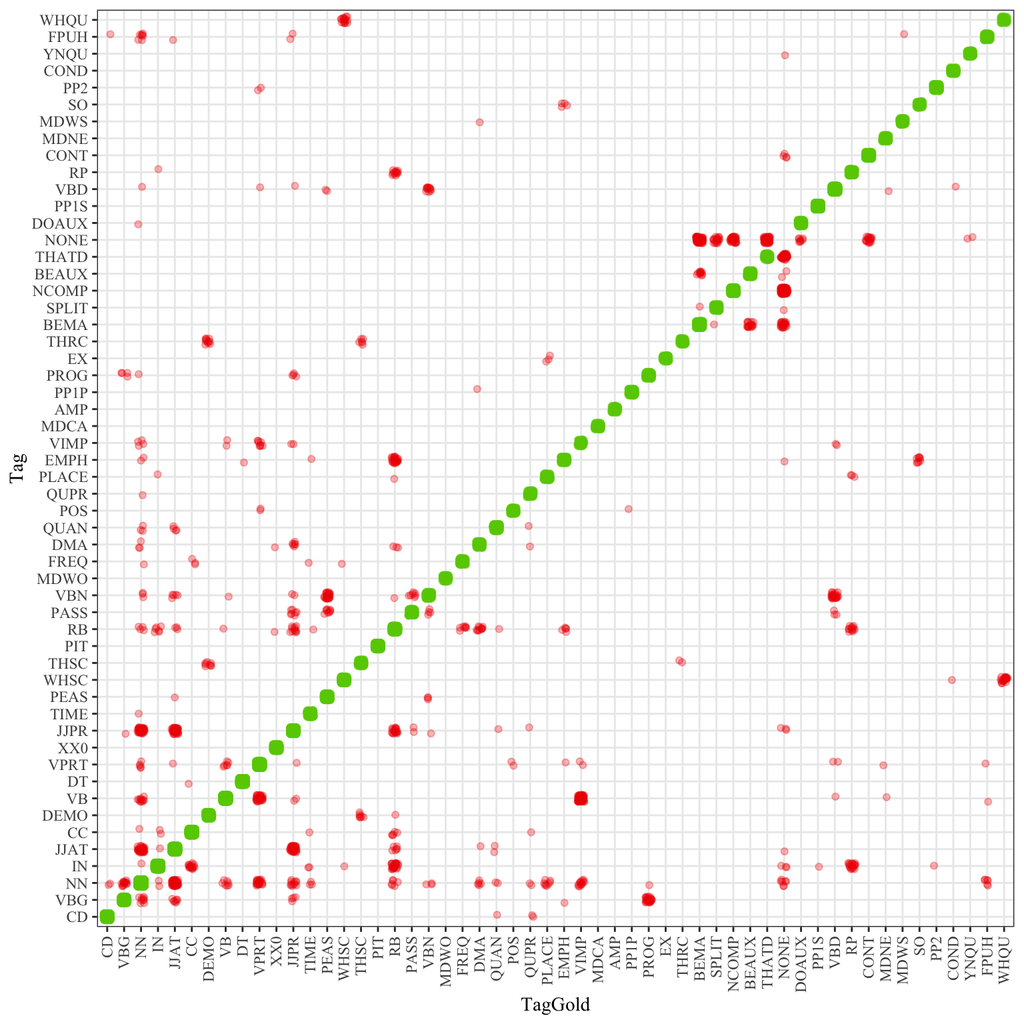

```r
min_n <- 100 # This can be dropped to 0 in order to print the full data matrix
jitter_dist <- 0.2
opacity <- 0.3

data_filtered1 <- EvalData %>%
  filter(!TagGold %in% c("UNCLEAR","unclear")) %>%
  filter(!TagGold %in% c("ACT", "NFP", "GW", "HYPH", "ADD", "AFX", "FW", "WQ", "SYM")) %>%
  filter(TagGold %in% c(str_extract(Tag, "[A-Z0-9]+"))) %>% # Remove all punctuation tags which are uninteresting here.
  add_count(Tag, name = "n_tagged") %>%
  add_count(TagGold, name = "n_tagged_gold") %>%
  filter(
    n_tagged >= min_n,
    n_tagged_gold >= min_n)

tags_remaining <- union(
  unique(data_filtered1$Tag),
  unique(data_filtered1$TagGold)
)

data_filtered2 <- data_filtered1 %>%
  mutate(
    Tag = factor(Tag, levels = tags_remaining),
    TagGold = factor(TagGold, levels = tags_remaining)) %>%
  arrange(TagGold)

library(extrafont)

error_fig <- data_filtered2 %>%
  ggplot(aes(x = TagGold, y = Tag, colour = Evaluation)) +
  theme_bw() +
  theme(axis.text.x = element_text(angle = 90, vjust = 0.5, hjust=1),
        text=element_text(family = "Times New Roman"),
        legend.position = "none") +
  scale_color_manual(values = c("red2", "chartreuse3")) +
  coord_fixed() +
  scale_x_discrete(drop = FALSE) +
  scale_y_discrete(drop = FALSE) +
  geom_jitter(
    #aes(size = n_tagged_gold),
    width = jitter_dist,
    height = jitter_dist,
    alpha = opacity)

error_fig
```

```r
#ggsave(here("plots", "TaggerErrorMatrix_TimesRoman.svg"), width = 9, height = 9)
```

## Comparing tagger accuracy across different registers

```r
registerEval <- function(data, register) {
  d <- data %>% filter(Register==register)
  cm <- caret::confusionMatrix(d$Tag, d$TagGold)
  return(round((cm$overall*100), 2))
  #return(cm$byClass[,5:7])
}

summary(data$Register)
```

```
##   academic e-language    fiction       news     spoken  TV/movies
##       4705      17137       5874      12975      10049       1908
```

```r
registerEval(data, "academic")
```

```
##       Accuracy          Kappa  AccuracyLower  AccuracyUpper   AccuracyNull
##          97.83          97.50          97.37          98.23          29.48
## AccuracyPValue  McnemarPValue
##           0.00            NaN
```

```r
registerEval(data, "e-language")
```

```
##       Accuracy          Kappa  AccuracyLower  AccuracyUpper   AccuracyNull
##          96.56          96.27          96.27          96.83          21.07
## AccuracyPValue  McnemarPValue
##           0.00            NaN
```

```r
registerEval(data, "fiction")
```

```
##       Accuracy          Kappa  AccuracyLower  AccuracyUpper   AccuracyNull
##          97.89          97.71          97.49          98.24          19.05
## AccuracyPValue  McnemarPValue
##           0.00            NaN
```

```r
registerEval(data, "news")
```

```
##       Accuracy          Kappa  AccuracyLower  AccuracyUpper   AccuracyNull
##          97.77          97.53          97.50          98.02          25.20
## AccuracyPValue  McnemarPValue
##           0.00            NaN
```

```r
registerEval(data, "spoken")
```

```
##       Accuracy          Kappa  AccuracyLower  AccuracyUpper   AccuracyNull
##          96.66          96.40          96.29          97.00          19.90
## AccuracyPValue  McnemarPValue
##           0.00            NaN
```

```r
registerEval(data, "TV/movies")
```

```
##       Accuracy          Kappa  AccuracyLower  AccuracyUpper   AccuracyNull
##          96.44          96.15          95.50          97.22          21.28
## AccuracyPValue  McnemarPValue
##           0.00            NaN
```

```r
dataSpoken <- data %>%
  filter(Register=="spoken" | Register=="TV/movies")
cmSpoken <- caret::confusionMatrix(dataSpoken$Tag, dataSpoken$TagGold)
round((cmSpoken$overall*100), 2)
```

```
##       Accuracy          Kappa  AccuracyLower  AccuracyUpper   AccuracyNull
##          96.62          96.36          96.28          96.94          20.12
## AccuracyPValue  McnemarPValue
##           0.00            NaN
```

```r
varietyEval <- function(data, variety) {
  d <- data %>% filter(Corpus==variety)
  cm <- caret::confusionMatrix(d$Tag, d$TagGold)
  return(round((cm$overall*100), 2))
  #return(cm$byClass[,5:7])
}

varietyEval(data, "BNC2014")
```

```
##       Accuracy          Kappa  AccuracyLower  AccuracyUpper   AccuracyNull
##          96.78          96.55          96.58          96.98          19.78
## AccuracyPValue  McnemarPValue
##           0.00            NaN
```

```r
varietyEval(data, "COCA")
```

```
##       Accuracy          Kappa  AccuracyLower  AccuracyUpper   AccuracyNull
##          97.56          97.28          97.36          97.76          25.63
## AccuracyPValue  McnemarPValue
##           0.00            NaN
```

## Comparing tagger accuracy across individual files

Note that this is not extremely informative because the individual test files really are quite short.

```r
fileEval <- function(data, file) {
  d <- data %>% filter(FileID==file) %>%
    # Ensure that the factor levels are the same for the next caret operation
    mutate(Tag = factor(Tag, levels = union(levels(Tag), levels(TagGold)))) %>%
  mutate(TagGold = factor(TagGold, levels = union(levels(Tag), levels(TagGold))))
  cm <- caret::confusionMatrix(d$Tag, d$TagGold)
  return(cm$overall)
  #return(cm$byClass[,5:7])
}

levels(data$FileID)
```

```
##  [1] "AcaHumBk34"           "BNC_BAcjH78"          "BNC_BAcjM107"
##  [4] "BNC_BEBl293"          "BNC_BEEm76"           "BNC_BERe31"
##  [7] "BNC_BFict_b2"         "BNC_BMass311"         "BNC_BReg495"
## [10] "BNC_BSer145"          "BNC_ElanBlogBla12"    "BNC_ElanBlogSlu30"
## [13] "BNC_ElanEmail102"     "BNC_ElanForumCar5"    "BNC_ElanForumRig1"
## [16] "BNC_ElanRev27"        "BNC_ElanSms33"        "BNC_ElanSocFac4_pt1"
## [19] "BNC_ElanSocTwi49_pt7" "BNC_ElanSocTwi6_pt4"  "BNC_FictFan41"
## [22] "BNC_FictMis228"       "BNC_MagAut1397"       "BNC_MagPc275"
## [25] "BNC_NewMaDas2819"     "BNC_NewReBet1393"     "BNC_NewSeGua553"
## [28] "BNC_Sp2m0f33"         "BNC_Sp2m2f63"         "BNC_Sp3m1f10"
## [31] "COCA_acad_4000541"    "COCA_acad_4017541"    "COCA_acad_4170341"
## [34] "COCA_blog_5157941"    "COCA_blog_5174141"    "COCA_blog_5176541"
## [37] "COCA_fict_1000441"    "COCA_fict_1003141"    "COCA_fict_5003241"
## [40] "COCA_mag_2029741"     "COCA_mag_2030941"     "COCA_mag_4180341"
## [43] "COCA_News_4087357"    "COCA_News_4087464"    "COCA_News_4087649"
## [46] "COCA_News_4087995"    "COCA_Opinion_4061065" "COCA_Opinion_4062489"
## [49] "COCA_Opinion_4079063" "COCA_Opinion_4090647" "COCA_Spoken_4082518"
## [52] "COCA_Spoken_4082551"  "COCA_Spoken_4082571"  "COCA_Spoken_4082646"
## [55] "COCA_tvm_5208241"     "COCA_tvm_5215441"     "COCA_tvm_5246241"
## [58] "COCA_web_5026941"     "COCA_web_5035341"     "COCA_web_5080941"
```

```r
fileEval(data, "COCA_Opinion_4079063")
```

```
##       Accuracy          Kappa  AccuracyLower  AccuracyUpper   AccuracyNull
##      0.9811966      0.9790030      0.9716691      0.9881794      0.2393162
## AccuracyPValue  McnemarPValue
##      0.0000000            NaN
```

```r
fileEval(data, "BNC_BAcjH78")
```

```
##       Accuracy          Kappa  AccuracyLower  AccuracyUpper   AccuracyNull
##   9.776786e-01   9.734541e-01   9.593341e-01   9.892453e-01   3.370536e-01
## AccuracyPValue  McnemarPValue
##  1.824115e-189            NaN
```

## Compute accuracy metrics per feature

The three accuracy metrics are recall, precision and F1 score.

```r
cm <- caret::confusionMatrix(data$Tag, data$TagGold)
cm$overall
```

```
##       Accuracy          Kappa  AccuracyLower  AccuracyUpper   AccuracyNull
##      0.9713379      0.9687257      0.9698769      0.9727467      0.2239781
## AccuracyPValue  McnemarPValue
##      0.0000000            NaN
```

```r
cm$byClass[,5:7]
```

```
##                Precision    Recall        F1
## Class: ABLE    1.0000000 1.0000000 1.0000000
## Class: AMP     1.0000000 1.0000000 1.0000000
## Class: BEAUX   0.9637883 0.9531680 0.9584488
## Class: BEMA    0.9675119 0.9257013 0.9461449
## Class: CC      0.9939693 0.9885496 0.9912521
## Class: CD      0.9961440 0.9948652 0.9955042
## Class: CONC    0.9857143 0.9324324 0.9583333
## Class: CUZ     1.0000000 0.9864865 0.9931973
## Class: DEMO    0.9856115 0.9664903 0.9759573
## Class: DMA     0.9501779 0.9335664 0.9417989
## Class: DOAUX   0.9957265 0.9668050 0.9810526
## Class: DT      0.9997175 0.9997175 0.9997175
## Class: DWNT    1.0000000 1.0000000 1.0000000
## Class: ELAB    1.0000000 1.0000000 1.0000000
## Class: EMPH    0.8571429 0.9561753 0.9039548
## Class: EX      0.9727273 1.0000000 0.9861751
## Class: FREQ    0.9723502 0.9678899 0.9701149
## Class: IN      0.9889745 0.9977145 0.9933252
## Class: JJAT    0.9614163 0.9480752 0.9546991
## Class: JJPR    0.8845361 0.9050633 0.8946820
## Class: MDCA    1.0000000 1.0000000 1.0000000
## Class: MDCO    1.0000000 1.0000000 1.0000000
## Class: MDMM    1.0000000 1.0000000 1.0000000
## Class: MDWO    1.0000000 1.0000000 1.0000000
## Class: NCOMP   0.9055192 0.9612711 0.9325626
## Class: NN      0.9852879 0.9882123 0.9867480
## Class: NONE    0.0000000 0.0000000       NaN
## Class: PASS    0.9381720 0.9748603 0.9561644
## Class: PEAS    0.9891304 0.9210526 0.9538784
## Class: PIT     1.0000000 1.0000000 1.0000000
## Class: PLACE   0.9785408 0.9500000 0.9640592
## Class: POS     0.9837838 0.9891304 0.9864499
## Class: PP1P    0.9975186 0.9975186 0.9975186
## Class: PPother 0.0000000        NA        NA
## Class: PROG    0.9660377 0.8919861 0.9275362
## Class: QUAN    0.9849398 0.9894100 0.9871698
## Class: QUPR    0.9949749 0.9611650 0.9777778
## Class: RB      0.9326733 0.8979981 0.9150073
## Class: SPLIT   0.9903382 0.9151786 0.9512761
```

[output cut: 19 more lines]

```
## Class: MDWS    0.9935065 0.9935065 0.9935065
## Class: PP2     0.9970588 0.9985272 0.9977925
## Class: SO      0.9669421 0.9285714 0.9473684
## Class: YNQU    0.9754601 0.9875776 0.9814815
## Class: EMO     1.0000000 0.9473684 0.9729730
## Class: FPUH    0.9491525 0.9613734 0.9552239
## Class: POLITE  1.0000000 0.9733333 0.9864865
## Class: WHQU    0.8571429 0.8067227 0.8311688
## Class: HDG     0.9705882 0.9565217 0.9635036
## Class: STPR    0.9333333 0.4117647 0.5714286
## Class: PGET    1.0000000 0.8000000 0.8888889
## Class: GTO     0.9736842 1.0000000 0.9866667
## Class: HGOT    1.0000000 0.9696970 0.9846154
## Class: HST     1.0000000 0.9684211 0.9839572
## Class: QUTAG   1.0000000 0.9117647 0.9538462
```

```r
confusion_matrix <- cm$table
total <- sum(confusion_matrix)
number_of_classes <- nrow(confusion_matrix)
correct <- diag(confusion_matrix)
total_actual_class <- apply(confusion_matrix, 2, sum)
total_pred_class <- apply(confusion_matrix, 1, sum)
# Precision = TP / all that were predicted as positive
precision <- correct / total_pred_class
# Recall = TP / all that were actually positive
recall <- correct / total_actual_class
# F1
f1 <- (2 * precision * recall) / (precision + recall)
# create data frame to output results
results <- data.frame(precision, recall, f1)
results
```

```
##         precision    recall        f1
## ABLE    1.0000000 1.0000000 1.0000000
## AMP     1.0000000 1.0000000 1.0000000
## BEAUX   0.9637883 0.9531680 0.9584488
## BEMA    0.9675119 0.9257013 0.9461449
## CC      0.9939693 0.9885496 0.9912521
## CD      0.9961440 0.9948652 0.9955042
## CONC    0.9857143 0.9324324 0.9583333
## CUZ     1.0000000 0.9864865 0.9931973
## DEMO    0.9856115 0.9664903 0.9759573
## DMA     0.9501779 0.9335664 0.9417989
## DOAUX   0.9957265 0.9668050 0.9810526
## DT      0.9997175 0.9997175 0.9997175
## DWNT    1.0000000 1.0000000 1.0000000
## ELAB    1.0000000 1.0000000 1.0000000
## EMPH    0.8571429 0.9561753 0.9039548
## EX      0.9727273 1.0000000 0.9861751
## FREQ    0.9723502 0.9678899 0.9701149
## IN      0.9889745 0.9977145 0.9933252
## JJAT    0.9614163 0.9480752 0.9546991
## JJPR    0.8845361 0.9050633 0.8946820
## MDCA    1.0000000 1.0000000 1.0000000
## MDCO    1.0000000 1.0000000 1.0000000
## MDMM    1.0000000 1.0000000 1.0000000
## MDWO    1.0000000 1.0000000 1.0000000
## NCOMP   0.9055192 0.9612711 0.9325626
## NN      0.9852879 0.9882123 0.9867480
## NONE    0.0000000 0.0000000       NaN
## PASS    0.9381720 0.9748603 0.9561644
## PEAS    0.9891304 0.9210526 0.9538784
## PIT     1.0000000 1.0000000 1.0000000
## PLACE   0.9785408 0.9500000 0.9640592
## POS     0.9837838 0.9891304 0.9864499
## PP1P    0.9975186 0.9975186 0.9975186
## PPother 0.0000000       NaN       NaN
## PROG    0.9660377 0.8919861 0.9275362
## QUAN    0.9849398 0.9894100 0.9871698
## QUPR    0.9949749 0.9611650 0.9777778
## RB      0.9326733 0.8979981 0.9150073
## SPLIT   0.9903382 0.9151786 0.9512761
```

[output cut: 19 more lines]

```
## MDWS    0.9935065 0.9935065 0.9935065
## PP2     0.9970588 0.9985272 0.9977925
## SO      0.9669421 0.9285714 0.9473684
## YNQU    0.9754601 0.9875776 0.9814815
## EMO     1.0000000 0.9473684 0.9729730
## FPUH    0.9491525 0.9613734 0.9552239
## POLITE  1.0000000 0.9733333 0.9864865
## WHQU    0.8571429 0.8067227 0.8311688
## HDG     0.9705882 0.9565217 0.9635036
## STPR    0.9333333 0.4117647 0.5714286
## PGET    1.0000000 0.8000000 0.8888889
## GTO     0.9736842 1.0000000 0.9866667
## HGOT    1.0000000 0.9696970 0.9846154
## HST     1.0000000 0.9684211 0.9839572
## QUTAG   1.0000000 0.9117647 0.9538462
```

```r
#write.csv(results, here("evaluation", "MFTEAccuracyResults.csv"))
```

## Compute accuracy metrics with bootstrapping

The idea of computing 95% confidence intervals on these accuracy metrics was inspired by the method and code presented in Picoral et al. (2021). Bootstrapping is applied to every combination of feature and metric to obtain 95% confidence intervals. The code to do so was originally written in R; however because it was incredibly slow and the {boot} library appeared to have some weird bugs that caused various errors, it was translated to run in Python. The script is included in the project’s repository and is entitled: `bootstrap_eval.py`.

The results of the `bootstrap_eval.py` Python script are plotted in the following chunk:

```r
# Import 95 CI data computed in `bootstrap_eval.py`.
resultsCI <- read.csv(here("evaluation", "MFTE_Python_Eval_CIs.csv"),
                      stringsAsFactors = TRUE)
head(resultsCI) # Check import
```

```
##    tag     n    metric     value     lower     upper valid
## 1   CD   779 precision 0.9961440 0.9912713 1.0000000  True
## 2  VBG   635 precision 0.9248120 0.9038663 0.9448803  True
## 3 JJAT  2234 precision 0.9614163 0.9532705 0.9690393  True
## 4   NN 11792 precision 0.9852879 0.9830964 0.9875117  True
## 5   IN  6563 precision 0.9889745 0.9864261 0.9913019  True
## 6   CC  1834 precision 0.9939693 0.9897950 0.9972618  True
```

```r
str(resultsCI) # Check factors
```

```
## 'data.frame':    165 obs. of  7 variables:
##  $ tag   : Factor w/ 55 levels "ACT","AMP","BEAUX",..: 6 48 18 25 17 5 9 46 12 51 ...
##  $ n     : int  779 635 2234 11792 6563 1834 567 1865 3540 2895 ...
##  $ metric: Factor w/ 3 levels "f1","precision",..: 2 2 2 2 2 2 2 2 2 2 ...
##  $ value : num  0.996 0.925 0.961 0.985 0.989 ...
##  $ lower : num  0.991 0.904 0.953 0.983 0.986 ...
##  $ upper : num  1 0.945 0.969 0.988 0.991 ...
##  $ valid : Factor w/ 2 levels "","True": 2 2 2 2 2 2 2 2 2 2 ...
```

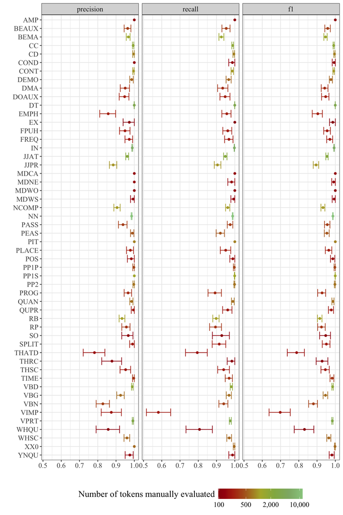

```r
# Remove NONE tag which was needed to calculate recall and precision but is not, in of itself of relevance to the evaluation results
resultsCI <- resultsCI %>%
  filter(tag != "NONE") %>%
  filter(tag != "VB") %>% # This feature is not listed in table of features and should therefore have been excluded earlier on
  filter(tag != "ACT") %>%  # This feature was moved to the extended tagset along with all other semantic verb tags and was therefore not included in the formal evaluation
  droplevels()

# Plot the accuracy metrics with bootstrapped 95% confidence intervals (portrait-format plot)
ggplot(resultsCI, aes(y = reorder(tag, desc(tag)),
                      x = value,
                      group = metric,
                      colour = n)) +
  geom_point() +
  geom_errorbar(aes(xmin=lower, xmax = upper)) +
  ylab("") +
  xlab("") +
  facet_wrap(~ factor(metric, c("precision", "recall", "f1"))) +
  scale_color_paletteer_c("harrypotter::harrypotter",
                          trans = "log",
                          breaks = c(110, 500, 2000, 10000),
                          labels = c("100", "500", "2,000", "10,000"),
                          name = "Number of tokens manually evaluated\n") +
  theme_bw() +
  theme(legend.position = "bottom",
        legend.key.width = unit(1, 'cm'),
        text = element_text(family = "Times New Roman",
                            size = 15))
```

```r
#ggsave(here("plots", "TaggerAccuracyResults95CI_portrait_TimesRoman.svg"), width = 8, height = 12) # For publication
```

## Qualitative analysis of tagger errors

```r
# Adding an error tag with the incorrectly assigned tag and underscore and then the correct "gold" label
errors <- data %>%
  filter(Evaluation=="FALSE") %>%
  mutate(Error = paste(Tag, TagGold, sep = " -> "))

# Total number of errors
nrow(errors) # 1509
```

```
## [1] 1509
```

```r
FreqErrors <- errors %>%
  count(Error) %>%
  arrange(desc(n))

FreqErrors %>%
  #group_by(Register) %>%
  filter(n > 9) %>%
  print.data.frame()
```

```
##            Error   n
## 1  NCOMP -> NONE 101
## 2   NONE -> BEMA  86
## 3     VB -> VIMP  75
## 4     NN -> JJAT  54
## 5     JJPR -> NN  42
## 6  THATD -> NONE  41
## 7   JJPR -> JJAT  40
## 8  NONE -> NCOMP  39
## 9  NONE -> THATD  38
## 10  JJAT -> JJPR  37
## 11    JJAT -> NN  37
## 12    VB -> VPRT  34
## 13   VBG -> PROG  29
## 14   VBN -> PEAS  28
```

[output cut: 25 more lines]

```r
errors %>%
  filter(Error == "NN -> JJAT") %>%
  select(-Output, -Corpus, -Tag, -TagGold) %>%
  filter(grepl(x = Token, pattern = "[A-Z]+.")) %>%
  print.data.frame()
```

```
##                  FileID   Register         Token Evaluation      Error
## 1            AcaHumBk34   academic      Cultural      FALSE NN -> JJAT
## 2          BNC_BAcjM107   academic     Cognitive      FALSE NN -> JJAT
## 3          BNC_BAcjM107   academic   Behavioural      FALSE NN -> JJAT
## 4          BNC_BAcjM107   academic      Positive      FALSE NN -> JJAT
## 5          BNC_BAcjM107   academic      Positive      FALSE NN -> JJAT
## 6          BNC_BAcjM107   academic Interpersonal      FALSE NN -> JJAT
## 7          BNC_BAcjM107   academic     Cognitive      FALSE NN -> JJAT
## 8          BNC_BAcjM107   academic   Behavioural      FALSE NN -> JJAT
## 9          BNC_BAcjM107   academic      National      FALSE NN -> JJAT
## 10         BNC_BAcjM107   academic      Clinical      FALSE NN -> JJAT
## 11           BNC_BEEm76 e-language     Cognitive      FALSE NN -> JJAT
## 12           BNC_BERe31 e-language         Great      FALSE NN -> JJAT
## 13         BNC_BFict_b2    fiction     Seductive      FALSE NN -> JJAT
## 14         BNC_BMass311       news         Civil      FALSE NN -> JJAT
## 15        BNC_ElanRev27 e-language          Nice      FALSE NN -> JJAT
## 16        BNC_ElanRev27 e-language         Royal      FALSE NN -> JJAT
## 17        BNC_ElanRev27 e-language          Nice      FALSE NN -> JJAT
## 18  BNC_ElanSocTwi6_pt4 e-language           Net      FALSE NN -> JJAT
## 19    COCA_acad_4017541   academic      ADVANCED      FALSE NN -> JJAT
## 20    COCA_acad_4017541   academic    GEOTHERMAL      FALSE NN -> JJAT
## 21    COCA_blog_5157941 e-language        Mighty      FALSE NN -> JJAT
## 22    COCA_blog_5174141 e-language       Eternal      FALSE NN -> JJAT
## 23    COCA_News_4087357       news      National      FALSE NN -> JJAT
## 24    COCA_News_4087649       news    Republican      FALSE NN -> JJAT
## 25 COCA_Opinion_4061065       news      Northern      FALSE NN -> JJAT
## 26  COCA_Spoken_4082518     spoken      American      FALSE NN -> JJAT
## 27  COCA_Spoken_4082571     spoken Technological      FALSE NN -> JJAT
## 28  COCA_Spoken_4082571     spoken    Electrical      FALSE NN -> JJAT
```

```r
errors %>%
  filter(Error %in% c("NN -> VB", "VB -> NN", "NN -> VPRT", "VPRT -> NN")) %>%
  count(Token) %>%
  arrange(desc(n)) %>%
  print.data.frame()
```

```
##       Token n
## 1   results 2
## 2      talk 2
## 3     Costs 2
## 4      show 2
## 5    evince 2
## 6      lead 1
## 7     spurs 1
## 8    become 1
## 9      head 1
## 10     work 1
## 11     help 1
## 12     love 1
## 13 accounts 1
## 14    plays 1
```

[output cut: 27 more lines]

```r
errors %>%
  filter(Error == "NN -> JJPR") %>%
  count(Token) %>%
  filter(grepl(x = Token, pattern = "[A-Z]+.")) %>%
  arrange(desc(n)) %>%
  print.data.frame()
```

```
##        Token n
## 1       Good 1
## 2      Great 1
## 3     Bright 1
## 4 Waterproof 1
```